# The National Agricultural Workers Survey (NAWS)

## NAWS data source

The source of this **NAWS** data: https://www.doleta.gov/naws/pages/public-data/public-data-codebook-and-questionnaire.cfm

## Load and combine data by farm workers ID

```r
laborA<- data.frame(read.csv("~/Downloads/NAWS_A2E185.csv"))
laborB<- data.frame(read.csv("~/Downloads/NAWS_F2Y185.csv"))
intersect(names(laborA),names(laborB))
```

```
## [1] "PWTYCRD" "FY"      "FWID"
```

```r
labor<-arrange( join(laborA,laborB) ,FWID)
laborA<-NULL
laborB<-NULL
labor<-subset(labor,select=-c(FWID,B14CODE,B15CODE,NT02COD,NQ02COD,PESTCONT))
labor<-labor[labor$FY==2015|2016,]
```

```r
dim(labor)
str(labor)
names(labor)
tail(labor,30)
```

### Preconditioning; convert the types of variables into factors

```r
nlev<-NULL
for (ii in 1:ncol(labor)) {
  nlev[ii]<-dim( table(labor[,ii]) )
  if ( nlev[ii] <=11 ) {
    labor[,ii]<-factor( labor[,ii] )
  }
  else labor[,ii]<-as.numeric( labor[,ii] )
}
toFacNames<-c("Birth_State","B17","B18","B26a","B26b","B27a","B27b","G01","G02","A09","FY")
for (jj in 1:length(toFacNames)) {
  labor[,toFacNames[jj]]<-factor( labor[,toFacNames[jj]] )
}
```

### Plots about wage

1. Wage as function of Age,
2. grouped by CROP

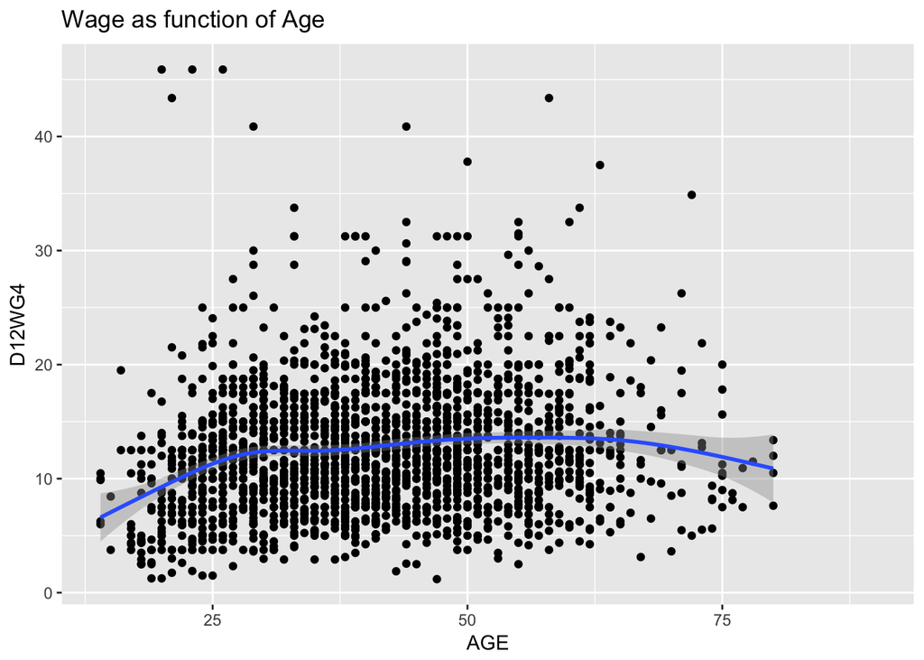

```r
qplot(AGE,D12WG4, data=labor,geom=c("point","smooth"),main="Wage as function of Age") # smooth:loess
```

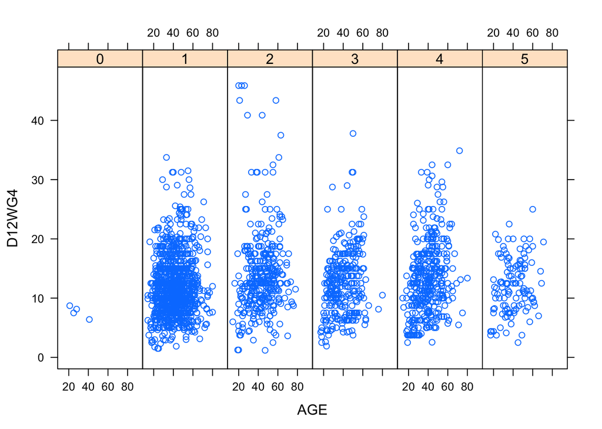

```r
xyplot(D12WG4~AGE|CROP, data=labor,layout=c(6,1))
```

CROP: 0=‘NON-SASAGRICULTURE’, 1=‘FIELD CROPS’, 2=‘FRUITS&NUTS’, 3=‘HORTICULTURE’, 4=‘VEGETABLES’, 5=‘MISC/MULT’

3. grouped by D37A: How far is your current job from your current residence? ( 1=I’m located at the job, 2=Within 9 miles, 3=10-24 miles, 4=25-49 miles, 5=50-74 miles, 6=75 miles or more )
4. grouped by A21a: Does the farm worker have health insurance? ( 0=no, 1=yes, 7=don’t know )

or A21b: Does the spouse have health insurance? ( 0=no, 1=yes, 7=don’t know )

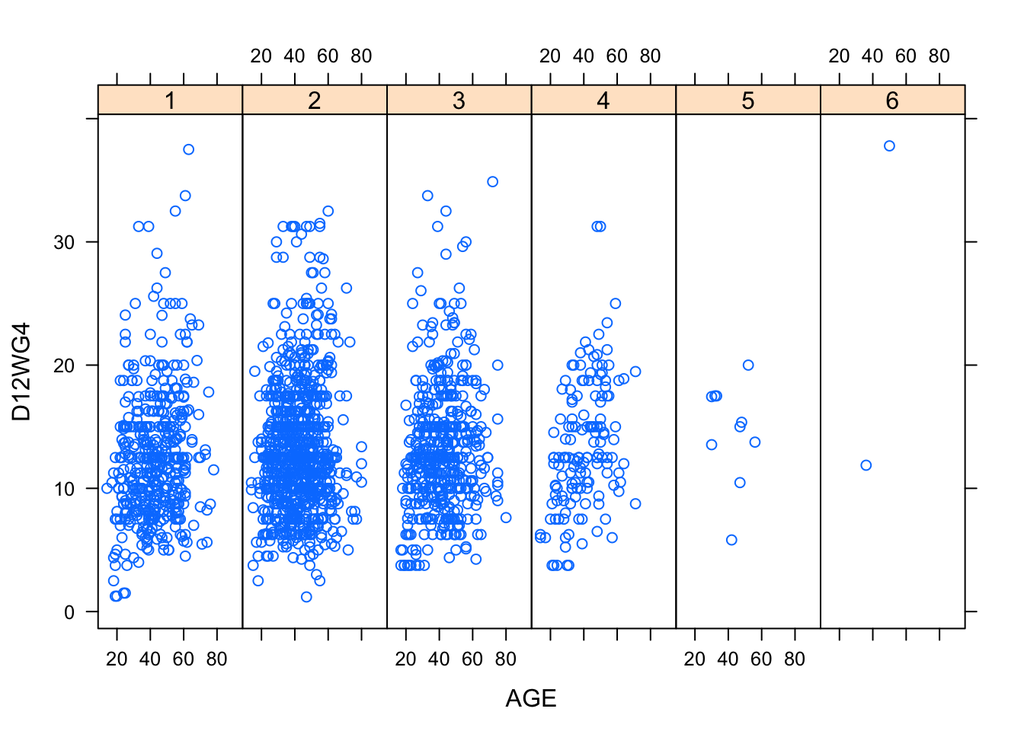

```r
xyplot(D12WG4~AGE|D37A, data=labor,layout=c(6,1))
```

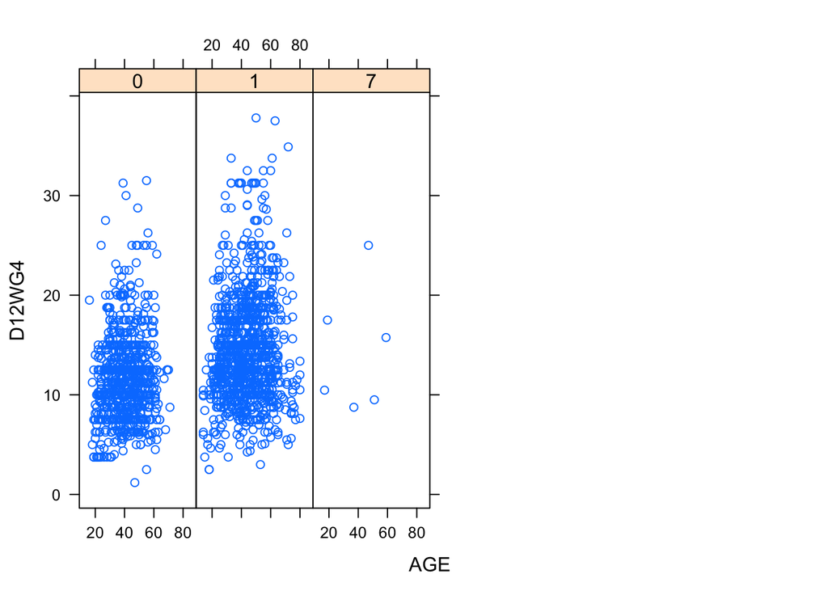

```r
#qplot(AGE,D12WG4, data=labor,color=D37A)

xyplot(D12WG4~AGE|A21a, data=labor,layout=c(6,1))
```

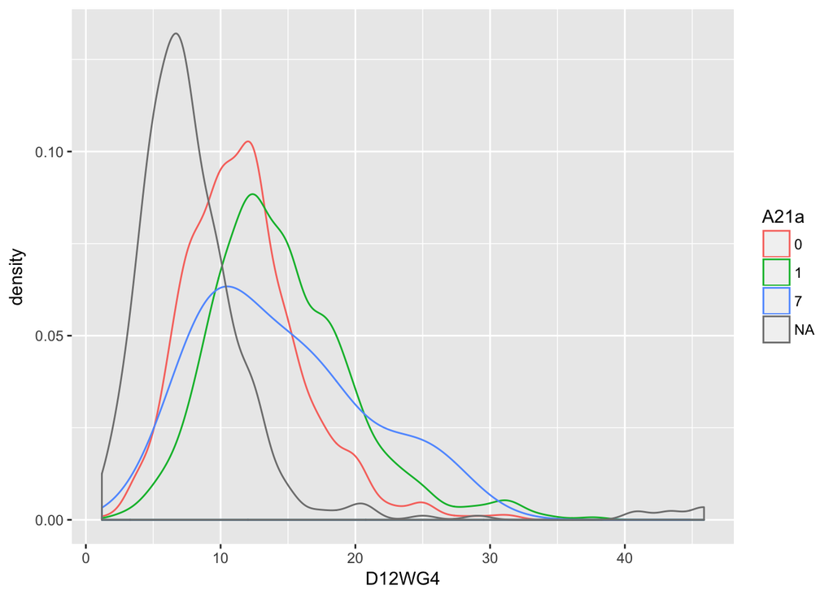

```r
qplot(D12WG4,data=labor,geom="density",color=A21a)
```

Check whether the farm worker and their spouses have health insurance: A21a: Does the farm worker have health insurance? ( 0=no, 1=yes, 7=don’t know ) A21b: Does the spouse have health insurance? ( 0=no, 1=yes, 7=don’t know )

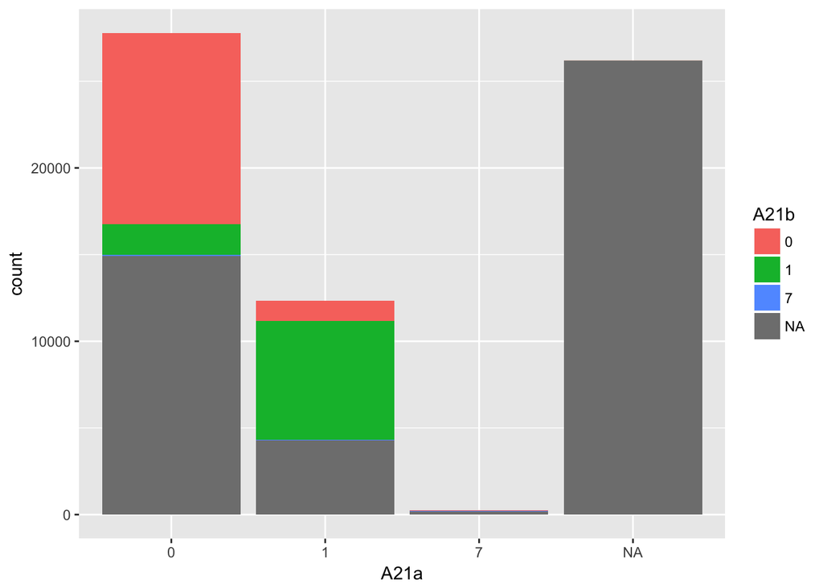

```r
qplot(A21a,data=labor,fill=A21b)
```

## Hypothesis testing for paired categorical variables

NP1F: In the last 12 months, have you loaded, mixed or applied pesticides?

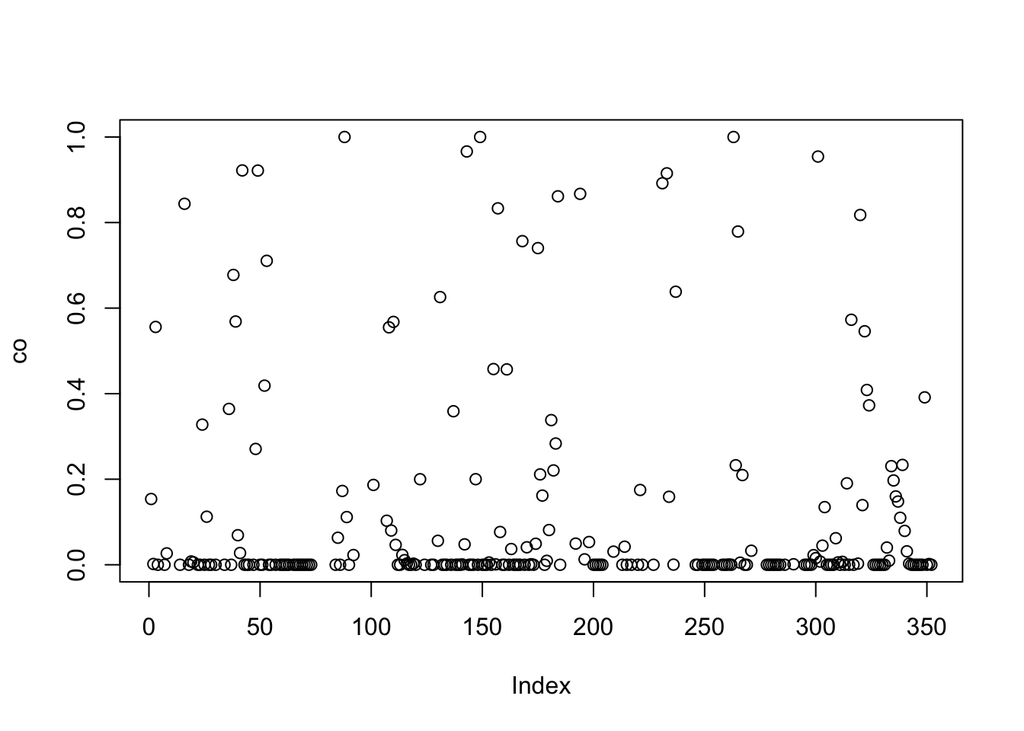

```r
co<-NULL
labor$NP01f<-as.factor(labor$NP01f)

for (ii in 1:ncol(labor)) {
  laborT<-as.data.frame(labor$NP01f)

  if ( dim(table(labor[,ii]))<=11 ) {

    laborT[,2]<-labor[,ii]
    laborT[,2]<-as.factor( laborT[,2] )
    names(laborT)[2]<-names(labor)[ii]
    #print(names(labor)[ii])
    bad<-rowSums( is.na(laborT) | laborT=="" )>0
    laborT<-laborT[!bad,]

    chisqRes<-chisq.test(table(laborT))
    co[ii]<-chisqRes$p.value
    #if (co[ii]>0.05){print(names(labor)[ii])}
  }
}
plot(co)
```

```r
print(names(labor)[!is.na(co) & co<0.05])
```

```
##   [1] "D36TFL12"       "currstat"       "ACCOMP"         "B17CODE"
##   [5] "BLWAGE"         "D50MTCOD"       "D51MTCOD"       "D38BFMT"
##   [9] "AGEFRSTFW"      "ChildOtherIndg" "AdultOtherIndg" "CROWDED1"
##  [13] "CROWDED2"       "EMPLOYED"       "D07"            "D20"
##  [17] "D21D"           "D22"            "D23"            "D26"
##  [21] "D28"            "D29C"           "D29D"           "D33A"
##  [25] "D35"            "D38"            "E04"            "E02"
##  [29] "A05"            "A07"            "A10"            "B03A"
##  [33] "B03B"           "B03D"           "B03E"           "B03F"
##  [37] "B03J"           "B07"            "B08"            "B01"
##  [41] "D11"            "D24"            "D37A"           "E01"
##  [45] "B04A"           "B04D"           "B04F"           "B04J"
##  [49] "B04K"           "B04L"           "B04N"           "B13"
##  [53] "A11"            "C10"            "D50"            "D36A13"
##  [57] "D36A14"         "A21a"           "A21b"           "A21cX"
```

[output cut: 29 more lines]

```r
#plot(co,ylim=c(0,1))
```

## Training with Random Forest

Here we select group B variables (Adult Education, Languages, Work Experience, Residence) to make models, predictions, confusion matrices

```r
labor %>% filter(FY==2016) %>% select( grep("^B0",names(labor)),NP01f) ->laborC

for (ii in 1:ncol(laborC)) {
  bad<-rowSums( is.na(laborC) | laborC=="" )>0
  laborC<-laborC[!bad,]
}

inTrain <- createDataPartition(y=laborC$NP01f, p=0.7, list=FALSE)
training <- laborC[inTrain, ]
testing <- laborC[-inTrain, ]
dim(training)
```

```
## [1] 1098   22
```

```r
dim(testing)
```

```
## [1] 469  22
```

```r
table(training$NP01f,useNA="ifany")
```

```
##
##   0   1
## 781 317
```

```r
ptm <- proc.time()
modRF<-train(NP01f~.,data=training,method="rf",ntree=10,tuneGrid=data.frame(mtry=6))
proc.time()-ptm
```

```
##    user  system elapsed
##   1.840   0.116   2.102
```

```r
predRF<-predict(modRF,testing)
confusionMatrix(predRF,testing$NP01f)
```

```
## Confusion Matrix and Statistics
##
##           Reference
## Prediction   0   1
##          0 311 122
##          1  23  13
##
##                Accuracy : 0.6908
##                  95% CI : (0.6468, 0.7324)
##     No Information Rate : 0.7122
##     P-Value [Acc > NIR] : 0.8577
##
##                   Kappa : 0.0351
##
##  Mcnemar's Test P-Value : 4.003e-16
##
##             Sensitivity : 0.9311
##             Specificity : 0.0963
##          Pos Pred Value : 0.7182
##          Neg Pred Value : 0.3611
##              Prevalence : 0.7122
##          Detection Rate : 0.6631
##    Detection Prevalence : 0.9232
##       Balanced Accuracy : 0.5137
##
##        'Positive' Class : 0
##
```

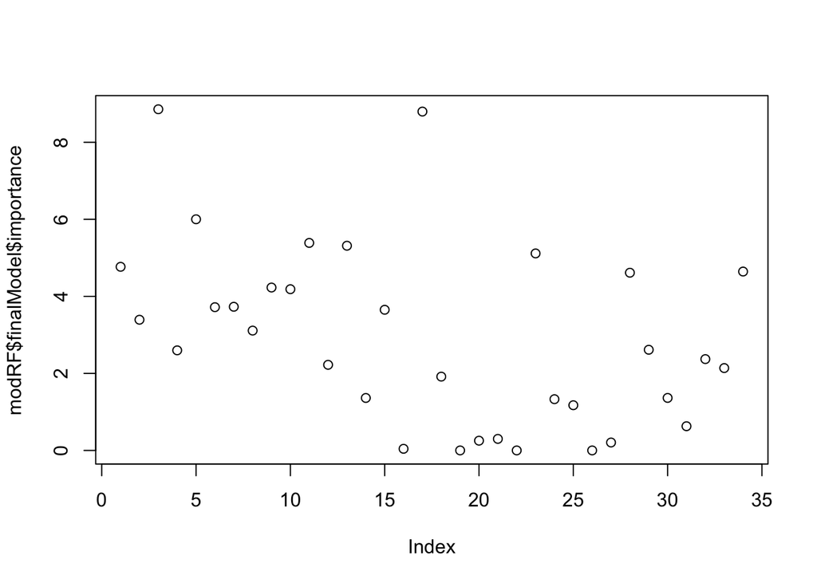

```r
plot(modRF$finalModel$importance)
```

```r
modRF$finalModel$importance
```

```
##       MeanDecreaseGini
## B03A1       4.76733669
## B03B1       3.39290337
## B03D1       8.85805148
## B03E1       2.59844255
## B03F1       6.00153333
## B03J1       3.71919208
## B072        3.72957635
## B073        3.11097524
## B074        4.22912624
## B082        4.18587981
## B083        5.38778338
## B084        2.22275019
## B012        5.31460907
## B013        1.36189106
## B014        3.65193369
## B015        0.04191133
## B017        8.79818472
## B022        1.91617319
## B023        0.00000000
## B024        0.25286396
## B025        0.29960881
## B026        0.00000000
## B027        5.11468194
## B03C1       1.33027638
## B03G1       1.17352009
## B03H1       0.00000000
## B03I1       0.20570473
## B04A1       4.61374633
## B04D1       2.61360146
## B04F1       1.36317477
## B04J1       0.62854108
## B04K1       2.37091993
## B04L1       2.13851339
## B04N1       4.64401949
```

B17: [IF FOREIGN BORN:] In what country (outside of the U.S.A.) did you live before coming to the U.S.A?

Here we select group G variables (Income and Assets) to make models, predictions, confusion matrices.

```r
labor %>% filter(FY==2016) %>% select( grep("^G0",names(labor)),NP01f) ->laborC

for (ii in 1:ncol(laborC)) {
  bad<-rowSums( is.na(laborC) | laborC=="" )>0
  laborC<-laborC[!bad,]
}

inTrain <- createDataPartition(y=laborC$NP01f, p=0.7, list=FALSE)
training <- laborC[inTrain, ]
testing <- laborC[-inTrain, ]
dim(training)
```

```
## [1] 1341   30
```

```r
dim(testing)
```

```
## [1] 574  30
```

```r
table(training$NP01f,useNA="ifany")
```

```
##
##    0    1
## 1019  322
```

```r
ptm <- proc.time()
modRF<-train(NP01f~.,data=training,method="rf",ntree=10,tuneGrid=data.frame(mtry=6))
proc.time()-ptm
```

```
##    user  system elapsed
##   2.755   0.154   2.961
```

```r
predRF<-predict(modRF,testing)
confusionMatrix(predRF,testing$NP01f)
```

```
## Confusion Matrix and Statistics
##
##           Reference
## Prediction   0   1
##          0 431 133
##          1   5   5
##
##                Accuracy : 0.7596
##                  95% CI : (0.7225, 0.794)
##     No Information Rate : 0.7596
##     P-Value [Acc > NIR] : 0.5228
##
##                   Kappa : 0.0363
##
##  Mcnemar's Test P-Value : <2e-16
##
##             Sensitivity : 0.98853
##             Specificity : 0.03623
##          Pos Pred Value : 0.76418
##          Neg Pred Value : 0.50000
##              Prevalence : 0.75958
##          Detection Rate : 0.75087
##    Detection Prevalence : 0.98258
##       Balanced Accuracy : 0.51238
##
##        'Positive' Class : 0
##
```

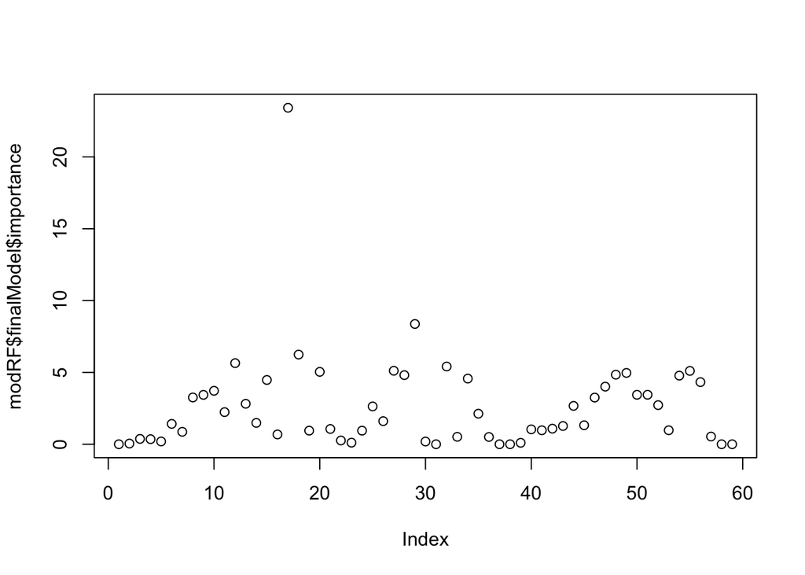

```r
plot(modRF$finalModel$importance)
```

```r
modRF$finalModel$importance
```

```
##       MeanDecreaseGini
## G011        0.00000000
## G012        0.04819872
## G013        0.37148597
## G014        0.35170862
## G015        0.19293109
## G016        1.41660268
## G017        0.86523045
## G018        3.25566407
## G019        3.43594854
## G0110       3.71929996
## G0111       2.23563414
## G0112       5.64514091
## G0113       2.81571003
## G0114       1.48548756
## G0115       4.47373227
## G0197       0.68196344
## G03        23.42086687
## G04B1       6.24132258
## G04C1       0.94596734
## G04D1       5.03935627
## G04E1       1.06232845
## G04F1       0.26110799
## G04G1       0.11005481
## G04H1       0.94419808
## G04N1       2.63318821
## G06A1       1.60679214
## G06C1       5.11377759
## G06B1       4.81033429
## G06D1       8.37193482
## G06E1       0.18765595
## G06F1       0.00000000
## G07A1       5.41110351
## G07C1       0.51589298
## G07B1       4.56951278
## G07D1       2.12686877
## G07E1       0.50587383
## G07F1       0.00000000
## G021        0.00000000
## G022        0.09937005
## G023        1.03513364
## G024        0.97044909
## G025        1.08470394
## G026        1.26926774
## G027        2.67022421
## G028        1.32141349
## G029        3.24837956
## G0210       4.00859257
## G0211       4.84049632
## G0212       4.96488463
## G0213       3.44080998
## G0214       3.44316703
## G0215       2.72238175
## G0297       0.97299983
## G04I1       4.77513375
## G04J1       5.10311249
## G04K1       4.32442235
## G04L1       0.53638094
## G04M1       0.00000000
## G04P1       0.00000000
```

G3: What was your FAMILY’S TOTAL INCOME last year in U.S.A. dollars (U.S.A. earners only)?